# Big Data in Finance: Part II (Lecture 1) Lecture Notes 2: Compustat

**Instructor**  
Lira Mota, lmota20@gsb.columbia.edu

**TA's:**  
Pu He, phe19@gsb.columbia.edu  
Daheng Yang, dyang22@gsb.columbia.edu

## Schedule

- Lecture 1: Compustat and CRSP
- Lecture 2: Factor Investing

## Homework

- The homework will be a replication exercise of Fama and French (2015) five factors (MktRF, SMB, HML, RMW, CMA) and Momentum.
- I will provide skeleton .py codes and you should develop your code filling the gaps of the code structure.
- How to deliver your homework? I what you to upload on Canvas a .zip file with:
  - your .py files,
  - .html file produced using jupyter notebooks with your results,
  - a log file with your git commits.

# Introduction

## Goal

1. Get familiar with Compustat and CRSP data bases;
2. Useful hacks to simplify your life;
3. One application in finance: factor investing.

# What is Compustat and CRSP?

## Compustat Description

- Compustat is a database of financial, statistical and market information on active and inactive global companies throughout the world. The service began in 1962.
- It is under the umbrella of Standard and Poor's many data sets: Compustat, Capital IQ, etc.
- What is the main use of Compustat data set in Finance? Firms' fundamentals.
  - In the US, all companies that have public traded securities must report accounting information in different formats, e.g., 10-K, 4-K.
  - Compustat is a compilation of information reported by firms in a standardized way.

  Source: [Compustat Website](https://wrds-www.wharton.upenn.edu/documents/841/Understanding_The_Data_57jARh2.pdf)
- **Compustat Xpressfeed** is a data delivery system for Standard & Poor’s Compustat data.

  As of June 2007, for the **U.S.** and **Canada** publicly-traded companies, Xpressfeed offers:
  - Coverage for over 14,650 active companies and over 16,950 inactive companies
  - Coverage for over 15,700 active securities and over 20,850 inactive securities
  - Company fundamental annual data beginning in 1950
  - Company restated quarterly beginning in 1962
  - Company annual summary data (rolling 10 years from current annual 10 K)
  - Daily and monthly market data beginning in 1984
  - Monthly market data beginning in 1962.
  - Fiscal and calendar presentations of data
  - Period data (3 months, 6 months, 9 months, 12 months)
  - Period and 12 months moving data for North America quarterly data.

  Source: [Compustat Website](https://wrds-www.wharton.upenn.edu/documents/841/Understanding_The_Data_57jARh2.pdf)
- As of June 2007, Xpressfeed offers the following International (excluding U.S. and Canadian) data:
  - Coverage for over 24,350 active companies and over 10,000 inactive companies
  - Coverage for over 25,900 active securities and over 13,250 inactive securities
  - Annual company fundamental data beginning in 1988
  - Historical semiannual company data beginning in 1996
  - Restated semi-annual company data beginning first quarter of 2005
  - Historical quarterly data beginning fourth quarter of 2003
  - Restated quarterly company data beginning first quarter of 2005
  - Daily market data beginning in 1984

## CRSP Description

- The CRSP U.S. Stock database contains end-of-day and month-end prices on primary listings for the NYSE, NYSE MKT, NASDAQ, and Arca exchanges, along with basic market indices. CRSP databases are characterized by their comprehensive corporate action information and highly accurate total return calculations.

Source: [Compustat Website](https://wrds-www.wharton.upenn.edu/pages/support/manuals-and-overviews/crsp/stocks-and-indices/overview-crsp-us-stock-database/)

- What can we find in CRSP?
  - Price and quote data (e.g. Open, close, bid/low, ask/high, trade-only)
  - Holding period returns with and without dividends
  - Excess returns and other derived data items
  - Market capitalization
  - Shares outstanding
  - Trading volume
  - Security delisting information
  - Corporate actions
  - Identifiers, descriptors, and supplemental data items
- One very valuable information: PERMNO/PERMCO
- CRSP Coverage:
  - Stocks (not bonds)
  - NYSE: All data series begin on December 31, 1925
  - NYSE MKT: All data series begin on July 2, 1962
  - NASDAQ: All data series begin on December 14, 1972
  - Arca: All data series begin March 8, 2006

# What is WRDS?

- Wharton Research Data Services

```python
from IPython.display import IFrame
IFrame('https://wrds-web.wharton.upenn.edu/wrds/', width=1500, height=500)
```

# Getting Started

```python
#%% Packages
import wrds
import datetime
import pandas as pd
import numpy as np
import matplotlib.pyplot as plt

import time
from time import strptime, strftime

# Setups
pd.set_option("display.max_rows", 100) # max number or rows to be displayed
%matplotlib inline
plt.rcParams['figure.figsize'] = [10, 6]
```

```python
#%% Set WRDS Connection
db = wrds.Connection(wrds_username='lmota') # make sure to configure wrds connector before hand.
```

```
Loading library list...
Done
```

```python
# List all libraries in WRDS
libs = db.list_libraries()
libs.__class__ # Notice that libs is a list.
libs = pd.DataFrame({'libraries':libs}) # Transform libs to a Pandas data frame to have a better display.
libs.sort_values(['libraries'])
```

|  | libraries |
| --- | --- |
| 0 | aha_sample |
| 1 | ahasamp |
| 2 | audit |
| 3 | audit_audit_comp |
| 4 | audit_corp_legal |
| 5 | block |
| 6 | boardex |
| 7 | boardex_eur |
| 8 | boardex_na |
| 9 | boardex_row |
| 10 | boardex_trial |
| 11 | boardex_uk |
| 12 | bvd |
| 13 | bvd_ama_large |
| 14 | bvd_ama_medium |
| 15 | bvd_ama_small |
| 16 | bvd_ama_verylarge |
| 17 | bvd_bvdbankf |
| 18 | bvd_orbis_large |
| 19 | bvd_orbis_medium |
| 20 | bvd_orbis_small |
| 21 | calcbench_trial |
| 22 | calcbnch |
| 23 | cboe |
| 24 | centris |
| 25 | ciq |
| 26 | ciq_common |
| 27 | ciq_keydev |
| 28 | ciq_ratings |
| 29 | clrvt |

[output cut: 71 more lines]

199 rows × 1 columns

## Compustat (S)

- comp
- comp_*
- compa: annual updates
- compm: monthly updates
- compd: daily updates (recommended with caution!)

## CRSP (S)

- crsp*
- crspa: annual updates
- crspm: monthly updates (our subscription includes this one at CBS)
- crspd: daily updates

# Compustat

In this section we are going to:

1. Download a set of US firm's annual fundamentals;
2. Understand how the data is organized:
   1. Primary keys;
   2. Secondary keys;
   3. Data frequency;
   4. Others.
3. Clean the data;
4. Construct important variables:
   1. Book Equity Value
   2. Asset Growth
   3. Operational Profitability

## How is the fundamentals data organized?

- We can display all tables in "compd" library.
- We are going to focus on the "funda" table: annual fundamentals.
- Others that are interesting to know: "namesd"

### All tables in compd

```python
compd_tables = db.list_tables(library="compd") # compd: Compustat daily update
pd.DataFrame({'tables':compd_tables}) # Transform libs to a Pandas data frame to have a better display.
```

|  | tables |
| --- | --- |
| 0 | aco_amda |
| 1 | aco_imda |
| 2 | aco_indfnta |
| 3 | aco_indfntq |
| 4 | aco_indfntytd |
| 5 | aco_indsta |
| 6 | aco_indstq |
| 7 | aco_indstytd |
| 8 | aco_notesa |
| 9 | aco_notesq |
| 10 | aco_notessa |
| 11 | aco_notesytd |
| 12 | aco_pnfnda |
| 13 | aco_pnfndq |
| 14 | aco_pnfndytd |
| 15 | aco_pnfnta |
| 16 | aco_pnfntq |
| 17 | aco_pnfntytd |
| 18 | aco_transa |
| 19 | aco_transq |
| 20 | aco_transsa |
| 21 | aco_transytd |
| 22 | adsprate |
| 23 | asec_amda |
| 24 | asec_imda |
| 25 | asec_notesa |
| 26 | asec_notesq |
| 27 | asec_transa |
| 28 | asec_transq |
| 29 | chars |

[output cut: 71 more lines]

199 rows × 1 columns

### All variables in compd.funda

```python
db.describe_table(library="compd", table="funda")
```

```
Approximately 793140 rows in compd.funda.
```

|  | name | nullable | type |
| --- | --- | --- | --- |
| 0 | gvkey | True | VARCHAR(6) |
| 1 | datadate | True | DATE |
| 2 | fyear | True | DOUBLE PRECISION |
| 3 | indfmt | True | VARCHAR(12) |
| 4 | consol | True | VARCHAR(2) |
| 5 | popsrc | True | VARCHAR(1) |
| 6 | datafmt | True | VARCHAR(12) |
| 7 | tic | True | VARCHAR(8) |
| 8 | cusip | True | VARCHAR(9) |
| 9 | conm | True | VARCHAR(57) |
| 10 | acctchg | True | VARCHAR(8) |
| 11 | acctstd | True | VARCHAR(8) |
| 12 | acqmeth | True | VARCHAR(2) |
| 13 | adrr | True | DOUBLE PRECISION |
| 14 | ajex | True | DOUBLE PRECISION |
| 15 | ajp | True | DOUBLE PRECISION |
| 16 | bspr | True | VARCHAR(8) |
| 17 | compst | True | VARCHAR(8) |
| 18 | curcd | True | VARCHAR(3) |
| 19 | curncd | True | VARCHAR(3) |
| 20 | currtr | True | DOUBLE PRECISION |
| 21 | curuscn | True | DOUBLE PRECISION |
| 22 | final | True | VARCHAR(2) |
| 23 | fyr | True | DOUBLE PRECISION |
| 24 | ismod | True | DOUBLE PRECISION |
| 25 | ltcm | True | VARCHAR(8) |
| 26 | ogm | True | VARCHAR(8) |
| 27 | pddur | True | DOUBLE PRECISION |
| 28 | scf | True | DOUBLE PRECISION |
| 29 | src | True | DOUBLE PRECISION |

[output cut: 71 more lines]

948 rows × 3 columns

#### Where to check variable definitions?

1. Xpressfeed Data Items
2. WRDS website: go to the (?) sign
3. What if we want to replicate a paper that says:

   "Earnings (E) is income before extraordinary items (Item 18) plus income statement deferred taxes (Item 50) minus preferred dividends (Item 19), if earnings are positive;" [Baker and Wurgler, JF 2006](https://onlinelibrary.wiley.com/doi/epdf/10.1111/j.1540-6261.2006.00885.x)
   - All previous documentation does not contain ITEM numbers
   - These are the legacy CST item numbers
   - Useful to check [here](http://www.crsp.com/products/documentation/annual-data-industrial)

#### Good Habit

- Make you paper replicable
  - Always write a data appendix
- Make sure that you can replicate your own work
  - Always write a data appendix
  - Comment your code

## Download the data

### First try

```python
fund_table = 'funda' # 'fundq' annual or quarterly
varlist = ['cusip', 'conm', 'fyear', 'fyr', 'fdate', 'apdedate', 'cik', 'at']
query_apple = """SELECT gvkey, datadate, {}
                 FROM compd.{}
                 WHERE GVKEY='001690'""".format(", ".join(varlist), fund_table)
print(query_apple)
del(fund_table, varlist)
```

```
SELECT gvkey, datadate, cusip, conm, fyear, fyr, fdate, apdedate, cik, at
                 FROM compd.funda
                 WHERE GVKEY='001690'
```

```python
compa = db.raw_sql(query_apple, date_cols=['datadate', 'fdate', 'apdedate'])
del(query_apple)
compa
```

|  | gvkey | datadate | cusip | conm | fyear | fyr | fdate | apdedate | cik | at |
| --- | --- | --- | --- | --- | --- | --- | --- | --- | --- | --- |
| 0 | 001690 | 1980-09-30 | 037833100 | APPLE INC | 1980.0 | 9.0 | NaT | NaT | 0000320193 | 65.350 |
| 1 | 001690 | 1981-09-30 | 037833100 | APPLE INC | 1981.0 | 9.0 | NaT | NaT | 0000320193 | 254.838 |
| 2 | 001690 | 1982-09-30 | 037833100 | APPLE INC | 1982.0 | 9.0 | NaT | NaT | 0000320193 | 357.787 |
| 3 | 001690 | 1983-09-30 | 037833100 | APPLE INC | 1983.0 | 9.0 | NaT | NaT | 0000320193 | 556.579 |
| 4 | 001690 | 1984-09-30 | 037833100 | APPLE INC | 1984.0 | 9.0 | NaT | NaT | 0000320193 | 788.786 |
| 5 | 001690 | 1985-09-30 | 037833100 | APPLE INC | 1985.0 | 9.0 | NaT | NaT | 0000320193 | 936.177 |
| 6 | 001690 | 1986-09-30 | 037833100 | APPLE INC | 1986.0 | 9.0 | NaT | NaT | 0000320193 | 1160.128 |
| 7 | 001690 | 1987-09-30 | 037833100 | APPLE INC | 1987.0 | 9.0 | NaT | NaT | 0000320193 | 1477.931 |
| 8 | 001690 | 1988-09-30 | 037833100 | APPLE INC | 1988.0 | 9.0 | NaT | NaT | 0000320193 | 2082.086 |
| 9 | 001690 | 1989-09-30 | 037833100 | APPLE INC | 1989.0 | 9.0 | NaT | NaT | 0000320193 | 2743.899 |
| 10 | 001690 | 1990-09-30 | 037833100 | APPLE INC | 1990.0 | 9.0 | NaT | NaT | 0000320193 | 2975.707 |
| 11 | 001690 | 1991-09-30 | 037833100 | APPLE INC | 1991.0 | 9.0 | NaT | NaT | 0000320193 | 3493.597 |
| 12 | 001690 | 1992-09-30 | 037833100 | APPLE INC | 1992.0 | 9.0 | NaT | NaT | 0000320193 | 4223.693 |
| 13 | 001690 | 1993-09-30 | 037833100 | APPLE INC | 1993.0 | 9.0 | NaT | NaT | 0000320193 | 5171.412 |
| 14 | 001690 | 1994-09-30 | 037833100 | APPLE INC | 1994.0 | 9.0 | NaT | NaT | 0000320193 | 5302.746 |
| 15 | 001690 | 1995-09-30 | 037833100 | APPLE INC | 1995.0 | 9.0 | NaT | NaT | 0000320193 | 6231.000 |
| 16 | 001690 | 1996-09-30 | 037833100 | APPLE INC | 1996.0 | 9.0 | NaT | NaT | 0000320193 | 5364.000 |
| 17 | 001690 | 1997-09-30 | 037833100 | APPLE INC | 1997.0 | 9.0 | NaT | NaT | 0000320193 | 4233.000 |
| 18 | 001690 | 1998-09-30 | 037833100 | APPLE INC | 1998.0 | 9.0 | NaT | NaT | 0000320193 | 4289.000 |
| 19 | 001690 | 1999-09-30 | 037833100 | APPLE INC | 1999.0 | 9.0 | NaT | NaT | 0000320193 | 5161.000 |
| 20 | 001690 | 2000-09-30 | 037833100 | APPLE INC | 2000.0 | 9.0 | NaT | NaT | 0000320193 | 6803.000 |
| 21 | 001690 | 2001-09-30 | 037833100 | APPLE INC | 2001.0 | 9.0 | NaT | NaT | 0000320193 | 6021.000 |
| 22 | 001690 | 2001-09-30 | 037833100 | APPLE INC | 2001.0 | 9.0 | NaT | NaT | 0000320193 | NaN |
| 23 | 001690 | 2002-09-30 | 037833100 | APPLE INC | 2002.0 | 9.0 | NaT | NaT | 0000320193 | NaN |
| 24 | 001690 | 2002-09-30 | 037833100 | APPLE INC | 2002.0 | 9.0 | NaT | NaT | 0000320193 | 6298.000 |
| 25 | 001690 | 2003-09-30 | 037833100 | APPLE INC | 2003.0 | 9.0 | NaT | 2003-09-27 | 0000320193 | 6815.000 |
| 26 | 001690 | 2003-09-30 | 037833100 | APPLE INC | 2003.0 | 9.0 | NaT | NaT | 0000320193 | NaN |
| 27 | 001690 | 2004-09-30 | 037833100 | APPLE INC | 2004.0 | 9.0 | NaT | 2004-09-25 | 0000320193 | 8050.000 |
| 28 | 001690 | 2004-09-30 | 037833100 | APPLE INC | 2004.0 | 9.0 | NaT | NaT | 0000320193 | NaN |
| 29 | 001690 | 2005-09-30 | 037833100 | APPLE INC | 2005.0 | 9.0 | NaT | 2005-09-24 | 0000320193 | 11551.000 |
| 30 | 001690 | 2005-09-30 | 037833100 | APPLE INC | 2005.0 | 9.0 | NaT | NaT | 0000320193 | NaN |
| 31 | 001690 | 2006-09-30 | 037833100 | APPLE INC | 2006.0 | 9.0 | 2007-01-01 | 2006-09-30 | 0000320193 | 17205.000 |
| 32 | 001690 | 2006-09-30 | 037833100 | APPLE INC | 2006.0 | 9.0 | NaT | NaT | 0000320193 | NaN |
| 33 | 001690 | 2007-09-30 | 037833100 | APPLE INC | 2007.0 | 9.0 | 2007-11-16 | 2007-09-29 | 0000320193 | 25347.000 |
| 34 | 001690 | 2007-09-30 | 037833100 | APPLE INC | 2007.0 | 9.0 | NaT | NaT | 0000320193 | NaN |
| 35 | 001690 | 2008-09-30 | 037833100 | APPLE INC | 2008.0 | 9.0 | 2008-11-05 | 2008-09-27 | 0000320193 | 39572.000 |
| 36 | 001690 | 2008-09-30 | 037833100 | APPLE INC | 2008.0 | 9.0 | NaT | NaT | 0000320193 | NaN |
| 37 | 001690 | 2009-09-30 | 037833100 | APPLE INC | 2009.0 | 9.0 | 2009-10-30 | 2009-09-26 | 0000320193 | 47501.000 |
| 38 | 001690 | 2009-09-30 | 037833100 | APPLE INC | 2009.0 | 9.0 | NaT | NaT | 0000320193 | 47501.000 |
| 39 | 001690 | 2010-09-30 | 037833100 | APPLE INC | 2010.0 | 9.0 | 2010-11-01 | 2010-09-25 | 0000320193 | 75183.000 |
| 40 | 001690 | 2010-09-30 | 037833100 | APPLE INC | 2010.0 | 9.0 | NaT | NaT | 0000320193 | 75183.000 |
| 41 | 001690 | 2011-09-30 | 037833100 | APPLE INC | 2011.0 | 9.0 | 2011-10-31 | 2011-09-24 | 0000320193 | 116371.000 |
| 42 | 001690 | 2011-09-30 | 037833100 | APPLE INC | 2011.0 | 9.0 | NaT | NaT | 0000320193 | 116371.000 |
| 43 | 001690 | 2012-09-30 | 037833100 | APPLE INC | 2012.0 | 9.0 | 2012-11-02 | 2012-09-29 | 0000320193 | 176064.000 |
| 44 | 001690 | 2012-09-30 | 037833100 | APPLE INC | 2012.0 | 9.0 | NaT | NaT | 0000320193 | 176064.000 |
| 45 | 001690 | 2013-09-30 | 037833100 | APPLE INC | 2013.0 | 9.0 | 2013-10-31 | 2013-09-28 | 0000320193 | 207000.000 |
| 46 | 001690 | 2013-09-30 | 037833100 | APPLE INC | 2013.0 | 9.0 | NaT | NaT | 0000320193 | 207000.000 |
| 47 | 001690 | 2014-09-30 | 037833100 | APPLE INC | 2014.0 | 9.0 | 2014-10-29 | 2014-09-27 | 0000320193 | 231839.000 |
| 48 | 001690 | 2014-09-30 | 037833100 | APPLE INC | 2014.0 | 9.0 | NaT | NaT | 0000320193 | 231839.000 |
| 49 | 001690 | 2015-09-30 | 037833100 | APPLE INC | 2015.0 | 9.0 | 2015-10-29 | 2015-09-26 | 0000320193 | 290479.000 |
| 50 | 001690 | 2015-09-30 | 037833100 | APPLE INC | 2015.0 | 9.0 | NaT | NaT | 0000320193 | 290345.000 |
| 51 | 001690 | 2016-09-30 | 037833100 | APPLE INC | 2016.0 | 9.0 | 2016-10-28 | 2016-09-24 | 0000320193 | 321686.000 |
| 52 | 001690 | 2016-09-30 | 037833100 | APPLE INC | 2016.0 | 9.0 | NaT | NaT | 0000320193 | 321686.000 |
| 53 | 001690 | 2017-09-30 | 037833100 | APPLE INC | 2017.0 | 9.0 | 2017-11-03 | 2017-09-30 | 0000320193 | 375319.000 |
| 54 | 001690 | 2017-09-30 | 037833100 | APPLE INC | 2017.0 | 9.0 | NaT | NaT | 0000320193 | 375319.000 |
| 55 | 001690 | 2018-09-30 | 037833100 | APPLE INC | 2018.0 | 9.0 | 2018-11-05 | 2018-09-29 | 0000320193 | 365725.000 |
| 56 | 001690 | 2018-09-30 | 037833100 | APPLE INC | 2018.0 | 9.0 | NaT | NaT | 0000320193 | 365725.000 |

### Second Try

Compustat Identifiers 1/2:

1. GVKEY: Global Company Name (Compustat company identifier)
2. DATADATE: Reporting date for a data record in Xpressfeed;
   - For example, for annual company data items this item equals the fiscal period end date. For security level data this item equals the trade date for high, low, close prices. This item is a key field used to retrieve specific data records from the database.
3. DATAFMT: Data Format Code
   - Refere to Xpressfeed Data Guide
   - It is very important for us that the data is Standardized in the same format.

Compustat Identifiers 2/2:

1. POPSRC: Used only for the North American population (POPSRC='D')
2. INDFMT: Whether a company reports in a Financial Services or Industrial format.
   - *"This allows you to view a company (such as Aetna) as an industrial company or as a financial serves company with all the associated data items, thus making it easier to dissect a company."*
3. CONSOL: Company's financial statements represent consolidated or nonconsolidated information.
   - In general, we are interested in the consolidated information.
   - consol='C'
- Look at the Apple example

```python
fund_table = 'funda'

varlist = ['cusip', 'conm', 'fyear', 'fyr', 'fdate', 'apdedate', 'cik', 'indfmt', 'datafmt', 'popsrc', 'consol','at']

query_apple = """SELECT gvkey, datadate, {}
                 FROM compd.{}
                 WHERE GVKEY='001690'
                 """.format(", ".join(varlist), fund_table)

compa = db.raw_sql(query_apple, date_cols=['datadate', 'fdate', 'apdedate'])

del(fund_table, query_apple)
```

- Download only what we need

```python
fund_table = 'funda'

varlist = ['cusip', 'conm', 'fyear', 'fyr', 'fdate', 'apdedate', 'cik','at']

query_apple = """SELECT gvkey, datadate, {}
                 FROM compd.{}
                 WHERE datafmt = 'STD'
                 AND popsrc = 'D'
                 AND indfmt = 'INDL'
                 AND consol = 'C'
                 AND GVKEY='001690';
                 """.format(", ".join(varlist), fund_table)

compa = db.raw_sql(query_apple, date_cols=['datadate', 'fdate', 'apdedate'])

del(fund_table, query_apple)

compa
```

|  | gvkey | datadate | cusip | conm | fyear | fyr | fdate | apdedate | cik | at |
| --- | --- | --- | --- | --- | --- | --- | --- | --- | --- | --- |
| 0 | 001690 | 1980-09-30 | 037833100 | APPLE INC | 1980.0 | 9.0 | NaT | NaT | 0000320193 | 65.350 |
| 1 | 001690 | 1981-09-30 | 037833100 | APPLE INC | 1981.0 | 9.0 | NaT | NaT | 0000320193 | 254.838 |
| 2 | 001690 | 1982-09-30 | 037833100 | APPLE INC | 1982.0 | 9.0 | NaT | NaT | 0000320193 | 357.787 |
| 3 | 001690 | 1983-09-30 | 037833100 | APPLE INC | 1983.0 | 9.0 | NaT | NaT | 0000320193 | 556.579 |
| 4 | 001690 | 1984-09-30 | 037833100 | APPLE INC | 1984.0 | 9.0 | NaT | NaT | 0000320193 | 788.786 |
| 5 | 001690 | 1985-09-30 | 037833100 | APPLE INC | 1985.0 | 9.0 | NaT | NaT | 0000320193 | 936.177 |
| 6 | 001690 | 1986-09-30 | 037833100 | APPLE INC | 1986.0 | 9.0 | NaT | NaT | 0000320193 | 1160.128 |
| 7 | 001690 | 1987-09-30 | 037833100 | APPLE INC | 1987.0 | 9.0 | NaT | NaT | 0000320193 | 1477.931 |
| 8 | 001690 | 1988-09-30 | 037833100 | APPLE INC | 1988.0 | 9.0 | NaT | NaT | 0000320193 | 2082.086 |
| 9 | 001690 | 1989-09-30 | 037833100 | APPLE INC | 1989.0 | 9.0 | NaT | NaT | 0000320193 | 2743.899 |
| 10 | 001690 | 1990-09-30 | 037833100 | APPLE INC | 1990.0 | 9.0 | NaT | NaT | 0000320193 | 2975.707 |
| 11 | 001690 | 1991-09-30 | 037833100 | APPLE INC | 1991.0 | 9.0 | NaT | NaT | 0000320193 | 3493.597 |
| 12 | 001690 | 1992-09-30 | 037833100 | APPLE INC | 1992.0 | 9.0 | NaT | NaT | 0000320193 | 4223.693 |
| 13 | 001690 | 1993-09-30 | 037833100 | APPLE INC | 1993.0 | 9.0 | NaT | NaT | 0000320193 | 5171.412 |
| 14 | 001690 | 1994-09-30 | 037833100 | APPLE INC | 1994.0 | 9.0 | NaT | NaT | 0000320193 | 5302.746 |
| 15 | 001690 | 1995-09-30 | 037833100 | APPLE INC | 1995.0 | 9.0 | NaT | NaT | 0000320193 | 6231.000 |
| 16 | 001690 | 1996-09-30 | 037833100 | APPLE INC | 1996.0 | 9.0 | NaT | NaT | 0000320193 | 5364.000 |
| 17 | 001690 | 1997-09-30 | 037833100 | APPLE INC | 1997.0 | 9.0 | NaT | NaT | 0000320193 | 4233.000 |
| 18 | 001690 | 1998-09-30 | 037833100 | APPLE INC | 1998.0 | 9.0 | NaT | NaT | 0000320193 | 4289.000 |
| 19 | 001690 | 1999-09-30 | 037833100 | APPLE INC | 1999.0 | 9.0 | NaT | NaT | 0000320193 | 5161.000 |
| 20 | 001690 | 2000-09-30 | 037833100 | APPLE INC | 2000.0 | 9.0 | NaT | NaT | 0000320193 | 6803.000 |
| 21 | 001690 | 2001-09-30 | 037833100 | APPLE INC | 2001.0 | 9.0 | NaT | NaT | 0000320193 | 6021.000 |
| 22 | 001690 | 2002-09-30 | 037833100 | APPLE INC | 2002.0 | 9.0 | NaT | NaT | 0000320193 | 6298.000 |
| 23 | 001690 | 2003-09-30 | 037833100 | APPLE INC | 2003.0 | 9.0 | NaT | 2003-09-27 | 0000320193 | 6815.000 |
| 24 | 001690 | 2004-09-30 | 037833100 | APPLE INC | 2004.0 | 9.0 | NaT | 2004-09-25 | 0000320193 | 8050.000 |
| 25 | 001690 | 2005-09-30 | 037833100 | APPLE INC | 2005.0 | 9.0 | NaT | 2005-09-24 | 0000320193 | 11551.000 |
| 26 | 001690 | 2006-09-30 | 037833100 | APPLE INC | 2006.0 | 9.0 | 2007-01-01 | 2006-09-30 | 0000320193 | 17205.000 |
| 27 | 001690 | 2007-09-30 | 037833100 | APPLE INC | 2007.0 | 9.0 | 2007-11-16 | 2007-09-29 | 0000320193 | 25347.000 |
| 28 | 001690 | 2008-09-30 | 037833100 | APPLE INC | 2008.0 | 9.0 | 2008-11-05 | 2008-09-27 | 0000320193 | 39572.000 |
| 29 | 001690 | 2009-09-30 | 037833100 | APPLE INC | 2009.0 | 9.0 | 2009-10-30 | 2009-09-26 | 0000320193 | 47501.000 |
| 30 | 001690 | 2010-09-30 | 037833100 | APPLE INC | 2010.0 | 9.0 | 2010-11-01 | 2010-09-25 | 0000320193 | 75183.000 |
| 31 | 001690 | 2011-09-30 | 037833100 | APPLE INC | 2011.0 | 9.0 | 2011-10-31 | 2011-09-24 | 0000320193 | 116371.000 |
| 32 | 001690 | 2012-09-30 | 037833100 | APPLE INC | 2012.0 | 9.0 | 2012-11-02 | 2012-09-29 | 0000320193 | 176064.000 |
| 33 | 001690 | 2013-09-30 | 037833100 | APPLE INC | 2013.0 | 9.0 | 2013-10-31 | 2013-09-28 | 0000320193 | 207000.000 |
| 34 | 001690 | 2014-09-30 | 037833100 | APPLE INC | 2014.0 | 9.0 | 2014-10-29 | 2014-09-27 | 0000320193 | 231839.000 |
| 35 | 001690 | 2015-09-30 | 037833100 | APPLE INC | 2015.0 | 9.0 | 2015-10-29 | 2015-09-26 | 0000320193 | 290479.000 |
| 36 | 001690 | 2016-09-30 | 037833100 | APPLE INC | 2016.0 | 9.0 | 2016-10-28 | 2016-09-24 | 0000320193 | 321686.000 |
| 37 | 001690 | 2017-09-30 | 037833100 | APPLE INC | 2017.0 | 9.0 | 2017-11-03 | 2017-09-30 | 0000320193 | 375319.000 |
| 38 | 001690 | 2018-09-30 | 037833100 | APPLE INC | 2018.0 | 9.0 | 2018-11-05 | 2018-09-29 | 0000320193 | 365725.000 |

- Always look at your data: plot, plot and plot

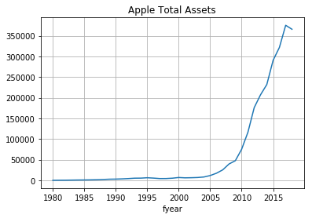

```python
compa.set_index('fyear')['at'].plot(title='Apple Total Assets', grid=True)
```